# Deliverable #3

# Introduction To Deliverable 3

For my Data Science project, I would like to take movies and try to see if I can predict a movie’s genre based off the summery of the movie to answer the question **Can you predict a genre of a movie based of a overview or summery of the movie?** I will define it as a success if I can find a trend in one genre that differs from other genre trends.

The data set I will be using will be a movie data set form TMDB (The Movie Data Base). The set contains over 45,000 data entries and 24 attributes. I will be using 11 of those attributes and be building more attributes from that data.

A weakness of the data set will be the 0 or null values for data points. Some are missing one or two attributes but have the rest of them. That is going to take a toll to my calculations when I try to compute an average or quantile of the whole data set.

Here are some important data attributes I will be using

`genre` - `string` - The genre of the movie. Can contain multiple

`id` - `integer` - Unique number id for the movie

`overview` - `string` - A description of the movie

`popularity` - `double` - The popularity of the movie

`original_title` - `string` - Title

`vote_average` - `double` - Average ratings the movie received.

`vote_count` - `integer` - The count of votes received.

#Data Analysis

Converts string version of list of dict if id(int) and names(string) from python to a char array of just the ids and names Only works if id is int and name is string

```r
#converts string version of list of dict if id(int) and names(string) from python to a char array of just the ids and names
#only works if id is int and name is string
ldictToDf <- function(tempList){
  tempList <- gsub("name","'", tempList)
  tempList <- gsub("id","'", tempList)
  tempList <- strsplit(tempList, "")[[1]]
  tempString <- c()
  for(x in seq(length(tempList))){
    if (tempList[x] != " " &tempList[x] != "," & tempList[x] != '}' & tempList[x] != '{' & tempList[x] != "'"
        & tempList[x] != ":"){
      tempString <- c(tempString, tempList[x])
    }
  }
  tempString <- tempString[-length(tempString)]
  tempString <- tempString[-1]
  idMovies <- c()
  nameMovies <- c()
  tempId <- ""
  tempName <- ""
  #False = id, True = name

  isnum <- TRUE
  for (ind in seq(length(tempString))) {
    if(isnum == TRUE){
      if(tempString[ind] >= '0' & tempString[ind] <= '9'){
        tempId <- paste(tempId,tempString[ind], sep = "")
      }
      else{
        idMovies <- c(idMovies,tempId)
        tempId <- ""
        isnum = FALSE
        tempName <- paste(tempName,tempString[ind],sep = "")
      }
    }
    else{
      if(tempString[ind] >= '0' & tempString[ind] <= '9'){
        nameMovies <- c(nameMovies,tempName)
        tempName <-""
        tempId <- paste(tempId,tempString[ind],sep = "")
        isnum = TRUE
      }
      else{
        if(tempString[ind] != '|'){
          tempName <- paste(tempName,tempString[ind],sep = "")
        }
      }
    }
  }
  nameMovies <- c(nameMovies,tempName)

  return(data.frame("id"= as.integer(idMovies), "name" = nameMovies))
}


movieTibble$genre_ids <- NA
movieTibble$genre_names <- NA
movieTibble$genre_ids <- as.list(movieTibble$genre_ids)
movieTibble$genre_names <- as.list(movieTibble$genre_names)

for(x in seq(length(movieTibble[[1]]))){
  if(nchar(movieTibble[["genres"]][x]) < 3){
    movieTibble[["genre_ids"]][x] <- list(-1)
    movieTibble[["genre_names"]][x] <- list("None")
  }
  else{
    tempDF = ldictToDf(movieTibble[["genres"]][x])
    movieTibble[["genre_ids"]][x] <- list(unname(unlist( tempDF[1]) ) )
    movieTibble[["genre_names"]][x] <- list(unname(unlist( tempDF[2]) ) )
  }
}
```

Gathering all the genres available

```r
allgenres <- c()
for(x in movieTibble$genre_names){
  for (v in x){
    if(!(v %in% allgenres)){
      allgenres <- c(allgenres, v)
    }
  }
}

allgenres
```

```
##  [1] "Animation"      "Comedy"         "Family"         "Adventure"
##  [5] "Fantasy"        "Romance"        "Drama"          "Action"
##  [9] "Crime"          "Thriller"       "Horror"         "History"
## [13] "ScienceFiction" "Mystery"        "War"            "Foreign"
## [17] "None"           "Music"          "Documentary"    "Western"
## [21] "TVMovie"
```

Putting all the columns from movieTibble in a smaller tibble with all the data im going to use

```r
workTibble <- select(movieTibble, budget,original_title,
                     overview,popularity, production_companies,
                     release_date, revenue, runtime, vote_average, vote_count, genre_ids,genre_names)
workTibble$release_date <-  as.Date(workTibble$release_date, "%Y-%m-%d")

workTibble <- movieTibble %>%
  select(budget,original_title,
                     overview,popularity, production_companies,
                     release_date, revenue, runtime, vote_average, vote_count, genre_ids,genre_names, original_language ) %>%
  filter(original_language == "en")
workTiibble <-  workTibble %>% distinct(original_title, .keep_all = TRUE)
workTibble$release_date <-  as.Date(workTibble$release_date, "%Y-%m-%d")
```

Testing to to see how to get count of movies in a genre

```r
animationCount <- 0
for (x in movieTibble$genre_names)
{
  for (v in x)
  {
    if(v == "Animation")
    {
        animationCount <- animationCount +1

    }
  }
}
```

I will filter out movie that have 0 votes so the average will be based on the movies that got votes

```r
workTibble <- filter(workTibble, vote_count > 0, vote_average > 0)
```

```r
#Because i have such a large dataset, i will be picking the top  70 movies from each genre based on vote_average

temp.workTibble <- filter(workTibble, original_title == "nothing")
temp.workTibble <-  select(temp.workTibble,original_title,overview,popularity,vote_average,vote_count,genre_names)
for(genreName in allgenres){
  temp <- workTibble %>%
    arrange(desc(vote_average)) %>%
    filter(genre_names %>%
             map(str_detect, genreName) %>%
             map_lgl(any))
  minimumVoteCount <- quantile(temp$vote_count, 0.85)[[1]]
  topChartTibble <- filter(temp, vote_count >= minimumVoteCount)
  temp.workTibble <- bind_rows(temp.workTibble,temp)
}

#and then remove duplicates that may have more than 1 genre

workTibble <-   temp.workTibble %>% distinct(original_title, .keep_all = TRUE)

#Lets take the top 95% of movies based on the vote count for the TopCharts system
minimumVoteCount <- quantile(filter(workTibble, vote_count > 0)$vote_count, 0.95)[[1]]

topChartTibble <- filter(workTibble, vote_count >= minimumVoteCount)

#adds weighted rating to each movie
meanVote <- mean(filter(workTibble, vote_average > 0)$vote_average)

#adds weighted rating to each movie based on IMDB' weighted rating. Used to balance voting averages with movies with a small number of votes
createWR <- function(votes, minVotes, avgRating, meanVote){
  return( ( ( votes/(votes+minVotes) )*avgRating) + ( (minVotes/(votes+minVotes) )*meanVote))
}

topChartTibble <-topChartTibble %>%
  mutate(weightedRating =  createWR(vote_count,minimumVoteCount,vote_average, meanVote))

#Print out top 10 rated movies
topChartTibble %>% arrange(desc(weightedRating)) %>%
  select(original_title,weightedRating,popularity,vote_average,vote_count) %>%
  head(10)
```

| original_title | weightedRating | popularity | vote_average | vote_count |
| --- | --- | --- | --- | --- |
| The Shawshank Redemption | 8.303414 | 51.64540 | 8.5 | 8358 |
| The Godfather | 8.235054 | 41.10926 | 8.5 | 6024 |
| The Dark Knight | 8.173372 | 123.16726 | 8.3 | 12269 |
| Fight Club | 8.141721 | 63.86960 | 8.3 | 9678 |
| Pulp Fiction | 8.124672 | 140.95024 | 8.3 | 8670 |
| Forrest Gump | 8.022081 | 48.30719 | 8.2 | 8147 |
| Inception | 7.998183 | 29.10815 | 8.1 | 14075 |
| Schindler's List | 7.979797 | 41.72512 | 8.3 | 4436 |
| Whiplash | 7.976004 | 64.29999 | 8.3 | 4376 |
| Interstellar | 7.973422 | 32.21348 | 8.1 | 11187 |

Now lets try and branch out our Top Rated list into certain genres. I’m going to bring down the quantile to 85% to allow more movies to be selected based off genres

```r
minimumVoteCount <- quantile(filter(workTibble, vote_count > 0)$vote_count, 0.85)[[1]]
topChartTibble <- filter(workTibble, vote_count >= minimumVoteCount)
meanVote <- mean(filter(workTibble, vote_average > 0)$vote_average)

topChartTibble <-topChartTibble %>%
  mutate(weightedRating =  createWR(vote_count,minimumVoteCount,vote_average, meanVote))

#This will give you the top 10 rated movies with the genre containing "Animation" From the topMovieList
topChartTibble %>% arrange(desc(weightedRating)) %>%
  filter(genre_names %>%
           map(str_detect, "Animation") %>%
           map_lgl(any)) %>%
  select(original_title,weightedRating,popularity,vote_average,vote_count) %>%
  head(10)
```

| original_title | weightedRating | popularity | vote_average | vote_count |
| --- | --- | --- | --- | --- |
| The Lion King | 7.951311 | 21.605761 | 8.0 | 5520 |
| Inside Out | 7.861859 | 23.985587 | 7.9 | 6737 |
| Up | 7.765350 | 19.330884 | 7.8 | 7048 |
| WALL·E | 7.762138 | 16.088366 | 7.8 | 6439 |
| Big Hero 6 | 7.761254 | 213.849907 | 7.8 | 6289 |
| Piper | 7.712780 | 11.243161 | 8.2 | 487 |
| Paperman | 7.682230 | 7.198633 | 8.0 | 734 |
| Toy Story | 7.657529 | 21.946943 | 7.7 | 5415 |
| Zootopia | 7.653743 | 26.024868 | 7.7 | 4961 |
| Song of the Sea | 7.577556 | 6.967358 | 8.1 | 420 |

Now i can create a function what spits out top movies given a genre

```r
topInGenre <- function(genreName){
  temp <- topChartTibble %>%
    arrange(desc(weightedRating)) %>%
    filter(genre_names %>%
             map(str_detect, genreName) %>%
             map_lgl(any)) %>%
    select(original_title,weightedRating,popularity,vote_average,vote_count,genre_names) %>%
    head(10)
  temp$genre_names <- genreName
  return(temp)
}
```

Lets use it to check out the Top Rated Horror movies based of the weighted rating

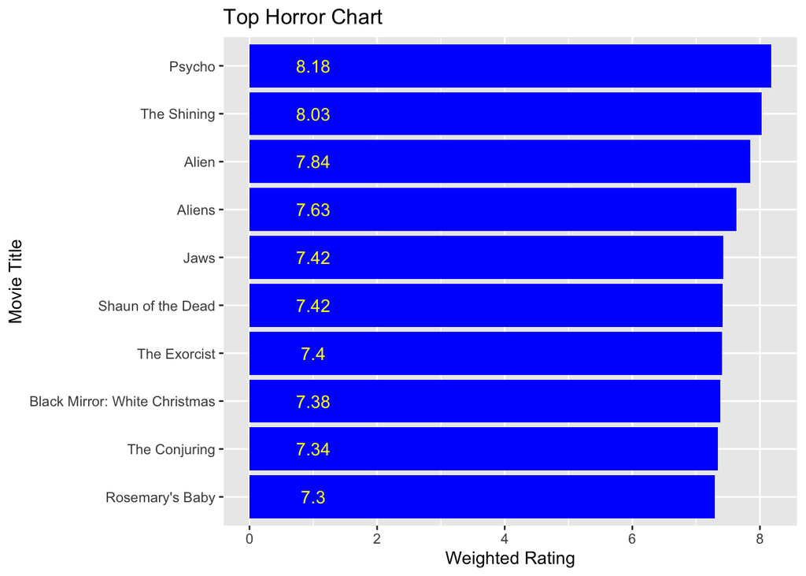

```r
plot.genre <- "Horror"
ggplot(data = topInGenre(plot.genre), mapping = aes(x =  weightedRating, y = reorder(original_title, weightedRating))) +
  geom_col( fill = "#0000FF") +
  ggtitle(paste("Top", plot.genre, "Chart")) +
  xlab("Weighted Rating") + ylab("Movie Title") +
  geom_text(aes(label=round(weightedRating, digits = 2)), x = 1,col="yellow")
```

Filter down once again for smaller data set

```r
topInGenre.list <- function(genreName){
  temp <- topChartTibble %>%
    arrange(desc(weightedRating)) %>%
    filter(genre_names %>%
             map(str_detect, genreName) %>%
             map_lgl(any)) %>%
    select(original_title,overview,weightedRating,popularity,vote_average,vote_count,genre_names) %>%
    head(70)
  return(temp)
}



temp.workTibble <- filter(workTibble, original_title == "nothing")
temp.workTibble <-  select(temp.workTibble,original_title,overview,popularity,vote_average,vote_count,genre_names)
for(genreName in allgenres){
  temp <- topInGenre.list(genreName)
  temp.workTibble <- bind_rows(temp.workTibble,temp)
}
workTibble <-   temp.workTibble %>% distinct(original_title, .keep_all = TRUE)
```

This functionality plots out the top movies in each genre (excluding movies with no genre at an attribute and The Top TVMovies)

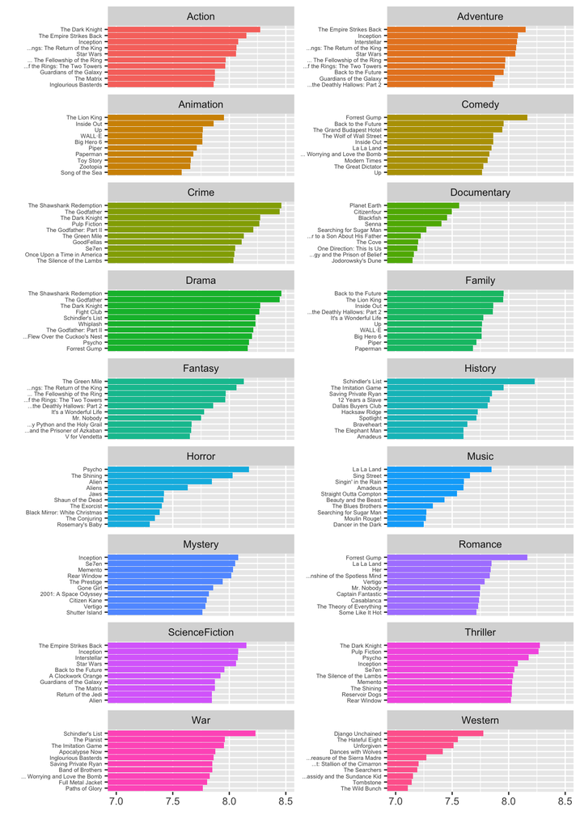

```r
#this function allows you to return the top movies in each genres from the top charts tibble
all.genre.plots <- function(){
  genreList <- allgenres[-1]
  plotting.tibble <-topInGenre(allgenres[1])
  for (g in seq( 2, length(allgenres) ) ) {
    plotting.tibble <- plotting.tibble %>% bind_rows(topInGenre(allgenres[g]))
  }
  return( plotting.tibble)
}
temp <- all.genre.plots()
ggplot(data = filter(temp, !genre_names %in% c("None", "TVMovie")),aes(x=reorder(str_trunc(original_title, 30, "left"), weightedRating), y = weightedRating)) +
  geom_col(aes(fill = genre_names), show.legend = FALSE) +
  coord_flip(y=c(7,8.5)) +
  facet_wrap(~genre_names, scales = "free_y", ncol = 2) +
  labs(x="", y="") +
  guides(size = FALSE) +
  theme(axis.text.y = element_text(size=5))
```

#Lets make a Summery Based Simulatiry model ##By content i mean the description of each movie

##Setting up data analytic text pipeline ##Making a token matrix will all the words in all the overviews

```r
train.tokens <- tokens(workTibble$overview, what = "word",
                       remove_numbers = TRUE, remove_punct = TRUE,
                       remove_symbols = TRUE, remove_hyphens = TRUE)
train.tokens[[1]]
```

```
##  [1] "A"       "young"   "lion"    "cub"     "named"   "Simba"   "can't"
##  [8] "wait"    "to"      "be"      "king"    "But"     "his"     "uncle"
## [15] "craves"  "the"     "title"   "for"     "himself" "and"     "will"
## [22] "stop"    "at"      "nothing" "to"      "get"     "it"
```

```r
#setting all the tokens to lowercase
train.tokens <- tokens_tolower(train.tokens)
train.tokens[[1]]
```

```
##  [1] "a"       "young"   "lion"    "cub"     "named"   "simba"   "can't"
##  [8] "wait"    "to"      "be"      "king"    "but"     "his"     "uncle"
## [15] "craves"  "the"     "title"   "for"     "himself" "and"     "will"
## [22] "stop"    "at"      "nothing" "to"      "get"     "it"
```

```r
#Removing "stopwords" like 'the' or 'and'. Those words provide no type of relative data to the movie

train.tokens <- tokens_select(train.tokens,stopwords(), selection = "remove")
train.tokens[[1]]
```

```
##  [1] "young"   "lion"    "cub"     "named"   "simba"   "wait"    "king"
##  [8] "uncle"   "craves"  "title"   "stop"    "nothing" "get"
```

```r
#stem the words bring downs words ending in 'ing' or 's' to break down to its root word
#for example in train.tokens[[1]], the word 'differences' change to "differ"
#this can create some problems tho with proper nouns. Names ending in y will be mutated to end in i
train.tokens <- tokens_wordstem(train.tokens, language = "english")
train.tokens[[1]]
```

```
##  [1] "young" "lion"  "cub"   "name"  "simba" "wait"  "king"  "uncl"  "crave"
## [10] "titl"  "stop"  "noth"  "get"
```

```r
train.tokens.dfm <- dfm(train.tokens,tolower = FALSE, remove = stopwords())

train.tokens.matrix <- as.matrix(train.tokens.dfm)
train.tokens.matrix[1:10,1:20]
```

```
##         features
## docs     young lion cub name simba wait king uncl crave titl stop noth get grow
##   text1      1    1   1    1     1    1    1    1     1    1    1    1   1    0
##   text2      0    0   0    0     0    0    0    0     0    0    0    0   0    1
##   text3      0    0   0    1     0    0    0    0     0    0    0    0   0    0
##   text4      0    0   0    0     0    0    0    0     0    0    0    0   0    0
##   text5      0    0   0    0     0    0    0    0     0    0    0    0   0    0
##   text6      0    0   0    0     0    0    0    0     0    0    0    0   0    0
##   text7      0    0   0    0     0    0    0    0     0    0    0    0   0    0
##   text8      0    0   0    0     0    0    0    0     0    0    0    0   0    0
##   text9      0    0   0    0     0    0    0    0     0    0    0    0   0    0
##   text10     0    0   0    0     0    0    0    0     0    0    0    0   0    0
##         features
## docs     can bumpi road except riley uproot
##   text1    0     0    0      0     0      0
##   text2    1     1    1      1     5      1
##   text3    0     0    0      0     0      0
##   text4    0     0    0      0     0      0
##   text5    0     0    0      0     0      0
##   text6    0     0    0      0     0      0
##   text7    0     0    0      0     0      0
##   text8    0     0    0      0     0      0
##   text9    0     0    0      0     0      0
##   text10   0     0    0      0     0      0
```

Now lets bind back those titles

```r
train.tokens.df <- cbind(Label = workTibble$original_title, convert(train.tokens.dfm, to = "data.frame"))

#fixing names of the df
names(train.tokens.df) <- make.names(names(train.tokens.df))
```

Now can create a Term Frequency Inverse Document Frequency with all the words in all the summeries

```r
#calculate termFrequency function
term.freq <- function(r){
  r/sum(r)
}

#calculate inverse document frequency

i.d.f <- function(c){
  size = length(c)
  document.size <- length(which(c>0))

  log10(size/document.size)
}


#combine functions to get tf-idf

tfidf <- function(termf,idf){
  termf*idf
}

#run the term.freq function against the rows
train.tokens.df <- apply(train.tokens.matrix, 1, term.freq)

train.tokens.df[1:20,1:20]
```

```
##         docs
## features      text1      text2      text3 text4 text5 text6 text7 text8 text9
##   young  0.07692308 0.00000000 0.00000000     0     0     0     0     0     0
##   lion   0.07692308 0.00000000 0.00000000     0     0     0     0     0     0
##   cub    0.07692308 0.00000000 0.00000000     0     0     0     0     0     0
##   name   0.07692308 0.00000000 0.03571429     0     0     0     0     0     0
##   simba  0.07692308 0.00000000 0.00000000     0     0     0     0     0     0
##   wait   0.07692308 0.00000000 0.00000000     0     0     0     0     0     0
##   king   0.07692308 0.00000000 0.00000000     0     0     0     0     0     0
##   uncl   0.07692308 0.00000000 0.00000000     0     0     0     0     0     0
##   crave  0.07692308 0.00000000 0.00000000     0     0     0     0     0     0
##   titl   0.07692308 0.00000000 0.00000000     0     0     0     0     0     0
##   stop   0.07692308 0.00000000 0.00000000     0     0     0     0     0     0
##   noth   0.07692308 0.00000000 0.00000000     0     0     0     0     0     0
##   get    0.07692308 0.00000000 0.00000000     0     0     0     0     0     0
##   grow   0.00000000 0.01515152 0.00000000     0     0     0     0     0     0
##   can    0.00000000 0.01515152 0.00000000     0     0     0     0     0     0
##   bumpi  0.00000000 0.01515152 0.00000000     0     0     0     0     0     0
##   road   0.00000000 0.01515152 0.00000000     0     0     0     0     0     0
##   except 0.00000000 0.01515152 0.00000000     0     0     0     0     0     0
##   riley  0.00000000 0.07575758 0.00000000     0     0     0     0     0     0
##   uproot 0.00000000 0.01515152 0.00000000     0     0     0     0     0     0
##         docs
## features text10     text11 text12 text13     text14 text15     text16 text17
##   young       0 0.02857143      0      0 0.00000000      0 0.03571429      0
##   lion        0 0.00000000      0      0 0.00000000      0 0.00000000      0
##   cub         0 0.00000000      0      0 0.00000000      0 0.00000000      0
##   name        0 0.00000000      0      0 0.00000000      0 0.00000000      0
##   simba       0 0.00000000      0      0 0.00000000      0 0.00000000      0
##   wait        0 0.00000000      0      0 0.00000000      0 0.00000000      0
##   king        0 0.00000000      0      0 0.02702703      0 0.00000000      0
##   uncl        0 0.00000000      0      0 0.00000000      0 0.00000000      0
##   crave       0 0.00000000      0      0 0.00000000      0 0.00000000      0
##   titl        0 0.00000000      0      0 0.00000000      0 0.00000000      0
##   stop        0 0.00000000      0      0 0.00000000      0 0.00000000      0
##   noth        0 0.00000000      0      0 0.00000000      0 0.00000000      0
##   get         0 0.00000000      0      0 0.00000000      0 0.00000000      0
##   grow        0 0.00000000      0      0 0.00000000      0 0.00000000      0
##   can         0 0.00000000      0      0 0.00000000      0 0.03571429      0
##   bumpi       0 0.00000000      0      0 0.00000000      0 0.00000000      0
```

[output cut: 11 more lines]

```
##   wait        0      0 0.00000000
##   king        0      0 0.00000000
##   uncl        0      0 0.00000000
##   crave       0      0 0.00000000
##   titl        0      0 0.00000000
##   stop        0      0 0.00000000
##   noth        0      0 0.00000000
##   get         0      0 0.00000000
##   grow        0      0 0.00000000
##   can         0      0 0.00000000
##   bumpi       0      0 0.00000000
##   road        0      0 0.00000000
##   except      0      0 0.00000000
##   riley       0      0 0.00000000
##   uproot      0      0 0.00000000
```

```r
#you can see the value of a word in on document are all the same. There value doesn't
#change in regard to the occurrence in other documents
#then run the idf against the cols
train.tokens.idf <- apply(train.tokens.matrix, 2, i.d.f)
str(train.tokens.idf)
```

```
##  Named num [1:5765] 0.962 2.559 2.86 1.112 2.86 ...
##  - attr(*, "names")= chr [1:5765] "young" "lion" "cub" "name" ...
```

```r
#then finally we conbine the two together

train.tokens.tfidf <- apply(train.tokens.df, 2, tfidf,idf = train.tokens.idf)

train.tokens.tfidf[1:20,1:20]
```

```
##         docs
## features      text1      text2      text3 text4 text5 text6 text7 text8 text9
##   young  0.07400857 0.00000000 0.00000000     0     0     0     0     0     0
##   lion   0.19682374 0.00000000 0.00000000     0     0     0     0     0     0
##   cub    0.21997989 0.00000000 0.00000000     0     0     0     0     0     0
##   name   0.08550389 0.00000000 0.03969823     0     0     0     0     0     0
##   simba  0.21997989 0.00000000 0.00000000     0     0     0     0     0     0
##   wait   0.14657662 0.00000000 0.00000000     0     0     0     0     0     0
##   king   0.13696595 0.00000000 0.00000000     0     0     0     0     0     0
##   uncl   0.16012210 0.00000000 0.00000000     0     0     0     0     0     0
##   crave  0.19682374 0.00000000 0.00000000     0     0     0     0     0     0
##   titl   0.19682374 0.00000000 0.00000000     0     0     0     0     0     0
##   stop   0.11827071 0.00000000 0.00000000     0     0     0     0     0     0
##   noth   0.13987276 0.00000000 0.00000000     0     0     0     0     0     0
##   get    0.08210361 0.00000000 0.00000000     0     0     0     0     0     0
##   grow   0.00000000 0.02645144 0.00000000     0     0     0     0     0     0
##   can    0.00000000 0.01922233 0.00000000     0     0     0     0     0     0
##   bumpi  0.00000000 0.03876831 0.00000000     0     0     0     0     0     0
##   road   0.00000000 0.02817786 0.00000000     0     0     0     0     0     0
##   except 0.00000000 0.03610026 0.00000000     0     0     0     0     0     0
##   riley  0.00000000 0.21664686 0.00000000     0     0     0     0     0     0
##   uproot 0.00000000 0.04332937 0.00000000     0     0     0     0     0     0
##         docs
## features text10    text11 text12 text13     text14 text15     text16 text17
##   young       0 0.0274889      0      0 0.00000000      0 0.03436112      0
##   lion        0 0.0000000      0      0 0.00000000      0 0.00000000      0
##   cub         0 0.0000000      0      0 0.00000000      0 0.00000000      0
##   name        0 0.0000000      0      0 0.00000000      0 0.00000000      0
##   simba       0 0.0000000      0      0 0.00000000      0 0.00000000      0
##   wait        0 0.0000000      0      0 0.00000000      0 0.00000000      0
##   king        0 0.0000000      0      0 0.04812317      0 0.00000000      0
##   uncl        0 0.0000000      0      0 0.00000000      0 0.00000000      0
##   crave       0 0.0000000      0      0 0.00000000      0 0.00000000      0
##   titl        0 0.0000000      0      0 0.00000000      0 0.00000000      0
##   stop        0 0.0000000      0      0 0.00000000      0 0.00000000      0
##   noth        0 0.0000000      0      0 0.00000000      0 0.00000000      0
##   get         0 0.0000000      0      0 0.00000000      0 0.00000000      0
##   grow        0 0.0000000      0      0 0.00000000      0 0.00000000      0
##   can         0 0.0000000      0      0 0.00000000      0 0.04530978      0
##   bumpi       0 0.0000000      0      0 0.00000000      0 0.00000000      0
```

[output cut: 11 more lines]

```
##   wait        0      0 0.00000000
##   king        0      0 0.00000000
##   uncl        0      0 0.00000000
##   crave       0      0 0.00000000
##   titl        0      0 0.00000000
##   stop        0      0 0.00000000
##   noth        0      0 0.00000000
##   get         0      0 0.00000000
##   grow        0      0 0.00000000
##   can         0      0 0.00000000
##   bumpi       0      0 0.00000000
##   road        0      0 0.00000000
##   except      0      0 0.00000000
##   riley       0      0 0.00000000
##   uproot      0      0 0.00000000
```

```r
#and finally we transpose it back to a term frequency matrix
train.tokens.tfidf <- t(train.tokens.tfidf)

#now we can say that the higher scores are going to be the more useful words if
# we are looking for similarity in movies

#BAD CASES
dim(train.tokens.tfidf)
```

```
## [1]  724 5765
```

```r
bad.case <- which(!complete.cases(train.tokens.tfidf))

workTibble$overview[bad.case]
```

```
## character(0)
```

```r
train.tokens.tfidf[bad.case,] <- rep(0.0,ncol(train.tokens.tfidf))
dim(train.tokens.tfidf)
```

```
## [1]  724 5765
```

```r
#thankfuly there were no bad or incomplete cases

#now lets clean a clean dataframe

train.tokens.tfidf.df <- cbind(Label = workTibble$original_title,data.frame(train.tokens.tfidf))

names(train.tokens.tfidf.df) <- make.names(names(train.tokens.tfidf.df))

train.tokens.tfidf.df[1:10,1:10]
```

|  | Label | young | lion | cub | name | simba | wait | king | uncl | crave |
| --- | --- | --- | --- | --- | --- | --- | --- | --- | --- | --- |
| text1 | The Lion King | 0.07400857 | 0.1968237 | 0.2199799 | 0.08550389 | 0.2199799 | 0.1465766 | 0.1369659 | 0.1601221 | 0.1968237 |
| text2 | Inside Out | 0.00000000 | 0.0000000 | 0.0000000 | 0.00000000 | 0.0000000 | 0.0000000 | 0.0000000 | 0.0000000 | 0.0000000 |
| text3 | Up | 0.00000000 | 0.0000000 | 0.0000000 | 0.03969823 | 0.0000000 | 0.0000000 | 0.0000000 | 0.0000000 | 0.0000000 |
| text4 | WALL·E | 0.00000000 | 0.0000000 | 0.0000000 | 0.00000000 | 0.0000000 | 0.0000000 | 0.0000000 | 0.0000000 | 0.0000000 |
| text5 | Big Hero 6 | 0.00000000 | 0.0000000 | 0.0000000 | 0.00000000 | 0.0000000 | 0.0000000 | 0.0000000 | 0.0000000 | 0.0000000 |
| text6 | Piper | 0.00000000 | 0.0000000 | 0.0000000 | 0.00000000 | 0.0000000 | 0.0000000 | 0.0000000 | 0.0000000 | 0.0000000 |
| text7 | Paperman | 0.00000000 | 0.0000000 | 0.0000000 | 0.00000000 | 0.0000000 | 0.0000000 | 0.0000000 | 0.0000000 | 0.0000000 |
| text8 | Toy Story | 0.00000000 | 0.0000000 | 0.0000000 | 0.00000000 | 0.0000000 | 0.0000000 | 0.0000000 | 0.0000000 | 0.0000000 |
| text9 | Zootopia | 0.00000000 | 0.0000000 | 0.0000000 | 0.00000000 | 0.0000000 | 0.0000000 | 0.0000000 | 0.0000000 | 0.0000000 |
| text10 | Song of the Sea | 0.00000000 | 0.0000000 | 0.0000000 | 0.00000000 | 0.0000000 | 0.0000000 | 0.0000000 | 0.0000000 | 0.0000000 |

This next part is a bit tricky. The library lsa has a cosine simularity function but it can only be used with two vectors where it compares them together or one full matrix where it compares each row to each other. So I took the data frame of the TF-IDF and created a martrix with it remove the titles of each row. Then I created a tibble with an index, similarity score, and a label. The label will be the title.

For those specific instance I decided to use the first row in the dataframe and compare it to all the other rows in a for loop, and then stored the score with the corespoding title in the cosine.score.tibble

```r
cosine.matrix <-data.matrix(train.tokens.tfidf.df[,2:dim(train.tokens.tfidf.df)[2]])


cosine.score.tibble <- tibble(index = integer(), score = numeric(), label = character())

for (x in seq(2:dim(train.tokens.tfidf.df)[1])) {
  tempScore <- cosine(c(cosine.matrix[x,1:dim(cosine.matrix)[2]]),c(cosine.matrix[1,1:dim(cosine.matrix)[2]] ))[1]
  cosine.score.tibble <- cosine.score.tibble %>% add_row(index = x, score = tempScore, label = train.tokens.tfidf.df[x,1])
}

cosine.score.tibble %>% arrange(-score)
```

| index | score | label |
| --- | --- | --- |
| 1 | 1.000000000 | The Lion King |
| 426 | 0.117091663 | The Addams Family |
| 375 | 0.102640667 | King Kong |
| 48 | 0.087374541 | Corpse Bride |
| 129 | 0.083090235 | Harry Potter and the Philosopher's Stone |
| 432 | 0.081364018 | The King's Speech |
| 355 | 0.077336077 | Man on Fire |
| 628 | 0.075921588 | The King of Kong |
| 108 | 0.072407949 | Hunt for the Wilderpeople |
| 26 | 0.065289837 | Batman: The Dark Knight Returns, Part 2 |

[output cut: 713 more lines]

So now we can compare the summery similarity of movies together. Now we take the ability of comparing movies and we use it to compare genre similarity

The way our data structures are formed rn need to change a bit. We can use built in functions to use the labels of the train.tokens.tfidf.df to signify a ordinal variable type to train the model, in this case, genre

#Final stretch ready… set… ‘makes coffee’… GO!

Start off with going through the train.tokens.tfidf.df and changing the labels to the genre

We need the watch the label withe the title in the worktibble and then change it to the genre with movies with multiple genres we make that make copies of the row with each genre Takes about 15 to run through

```r
testTokens <- filter(train.tokens.tfidf.df, Label == "nothing")

for (rowNum in seq(1:dim(train.tokens.tfidf.df)[1])){
  for (gens in seq(length(workTibble$genre_names[[ rowNum]]))) {
    tempToken <- train.tokens.tfidf.df[rowNum, 1:dim(train.tokens.tfidf.df)[2]]
    tempToken$Label <- workTibble$genre_names[[ rowNum]][gens]
    testTokens <- rbind(testTokens, tempToken)
  }
}

testTokens[1:10,1:10]
```

|  | Label | young | lion | cub | name | simba | wait | king | uncl | crave |
| --- | --- | --- | --- | --- | --- | --- | --- | --- | --- | --- |
| text1 | Family | 0.07400857 | 0.1968237 | 0.2199799 | 0.08550389 | 0.2199799 | 0.1465766 | 0.1369659 | 0.1601221 | 0.1968237 |
| text11 | Animation | 0.07400857 | 0.1968237 | 0.2199799 | 0.08550389 | 0.2199799 | 0.1465766 | 0.1369659 | 0.1601221 | 0.1968237 |
| text12 | Drama | 0.07400857 | 0.1968237 | 0.2199799 | 0.08550389 | 0.2199799 | 0.1465766 | 0.1369659 | 0.1601221 | 0.1968237 |
| text2 | Drama | 0.00000000 | 0.0000000 | 0.0000000 | 0.00000000 | 0.0000000 | 0.0000000 | 0.0000000 | 0.0000000 | 0.0000000 |
| text21 | Comedy | 0.00000000 | 0.0000000 | 0.0000000 | 0.00000000 | 0.0000000 | 0.0000000 | 0.0000000 | 0.0000000 | 0.0000000 |
| text22 | Animation | 0.00000000 | 0.0000000 | 0.0000000 | 0.00000000 | 0.0000000 | 0.0000000 | 0.0000000 | 0.0000000 | 0.0000000 |
| text23 | Family | 0.00000000 | 0.0000000 | 0.0000000 | 0.00000000 | 0.0000000 | 0.0000000 | 0.0000000 | 0.0000000 | 0.0000000 |
| text3 | Animation | 0.00000000 | 0.0000000 | 0.0000000 | 0.03969823 | 0.0000000 | 0.0000000 | 0.0000000 | 0.0000000 | 0.0000000 |
| text31 | Comedy | 0.00000000 | 0.0000000 | 0.0000000 | 0.03969823 | 0.0000000 | 0.0000000 | 0.0000000 | 0.0000000 | 0.0000000 |
| text32 | Family | 0.00000000 | 0.0000000 | 0.0000000 | 0.03969823 | 0.0000000 | 0.0000000 | 0.0000000 | 0.0000000 | 0.0000000 |

Now we see in our data that we have copies of each movie with their specified genre

we can train our model now with stratified cross validation because the representation of each genre is not proportional to each other meaning that we dont have an equal or close to equal number of movies for each genre so we wanna train out model with that in account

We’re going to do 10 fold cross validation 3 times because we can get more accurate results as long as we can take the computational hit time wise Used the Labels to select the correct proportions of the genres

```r
cv.folds <- createMultiFolds(testTokens$Label, k=10, times = 3)

cv.trainModel <- trainControl(method = "repeatedcv", number = 10,repeats = 3, index = cv.folds)


train.part.1 <- train(Label ~ .,data = testTokens, method = "rpart", trControl = cv.trainModel, tuneLength = 7 )


train.part.1
```

```
## CART
##
## 2066 samples
## 5765 predictors
##   20 classes: 'Action', 'Adventure', 'Animation', 'Comedy', 'Crime', 'Documentary', 'Drama', 'Family', 'Fantasy', 'History', 'Horror', 'Music', 'Mystery', 'None', 'Romance', 'ScienceFiction', 'Thriller', 'TVMovie', 'War', 'Western'
##
## No pre-processing
## Resampling: Cross-Validated (10 fold, repeated 3 times)
## Summary of sample sizes: 1860, 1859, 1859, 1857, 1863, 1860, ...
## Resampling results across tuning parameters:
##
##   cp            Accuracy   Kappa
##   0.0005913661  0.1344107  0.007919675
##   0.0009461857  0.1555415  0.027485771
##   0.0011827321  0.1646138  0.032724634
##   0.0015769761  0.1802070  0.038612587
##   0.0017740982  0.1815056  0.036798547
##   0.0023654642  0.1863436  0.022262666
##   0.0100532229  0.1826512  0.002056251
##
## Accuracy was used to select the optimal model using the largest value.
## The final value used for the model was cp = 0.002365464.
```

Here we see the results of the trained model cp is the complexity parameter which tries to control the size, number of splits, of the tree. The default value starts at 0.01 and adjusts every resampling to to try and improve accuracy

The Accuracy is how accurate our model is to predicting the genre of the movie

And the Kappa is a metric that compares observed Accuracy with an Expected accuracy Its not relevant enough to describe for this model

We can observe the comparison between the cp parameter and the accuracy of the model with the corresponding cp

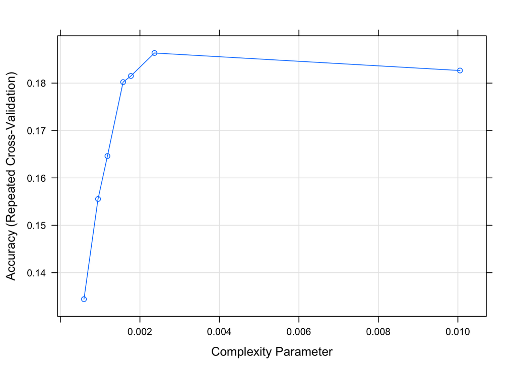

```r
plot(train.part.1)
```

Next we can plot the final model that was created

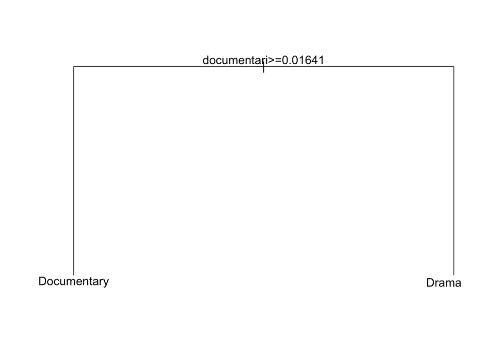

```r
par(xpd = NA)
plot(train.part.1$finalModel)

text(train.part.1$finalModel)
```

We can see with the model we’ve generated with the overviews, the only word that had significant value with its corresponding genre was the word ‘documentari’ which before reprocessing was the word documentary

looking at the results of out model, we can predict the genre of the movie from its overview with 18% accuracy, which respectfully is not good enough by any means to say that we can predict a movies genre with the contents of its overview from this method

I would like to go back to the cosine similarity score between the movies and make a new tibble with the scored for each movie. Instead of putting the movies as the columns too making it number of movies by number of movies, i want to calculate the scores and then add up the scored that came from one genre and divide by the number of movies from that genre, giving me the average similarity score from that genre to that movie and making the tibble number of movies by number of genres.

The goal of this approach is to see if the average similarity score of a movie from other movies in the same genre is significantly higher than other average genre similarity scores

First lets grab the tfidf matrix with the titles again, I am showing this again to walk through my process Heres the first 10 movies and 10 words in the matrix with the scores

```r
train.tokens.tfidf.df[1:10,1]
```

```
##  [1] "The Lion King"   "Inside Out"      "Up"              "WALL·E"
##  [5] "Big Hero 6"      "Piper"           "Paperman"        "Toy Story"
##  [9] "Zootopia"        "Song of the Sea"
```

```r
#next, lets create the tibble with the movies titles. We will call that column titles
sim.score.avgs <- as_tibble(train.tokens.tfidf.df[,1])
sim.score.avgs <- rename(sim.score.avgs,titles = value)

sim.score.avgs
```

| titles |
| --- |
| The Lion King |
| Inside Out |
| Up |
| WALL·E |
| Big Hero 6 |
| Piper |
| Paperman |
| Toy Story |
| Zootopia |
| Song of the Sea |

[output cut: 714 more lines]

```r
#next lets create a column for each genre. We have each genre in a saved variable
# but theres some weird properties woth adding column names from values in an array
# so hang with me me here while I jerry rig making a seperate column for every
# word in genre vector


for (x in allgenres){
  sim.score.avgs <- sim.score.avgs %>% add_column(temp = 0.0)
  names(sim.score.avgs)[length(sim.score.avgs)] <- x
}

sim.score.avgs
```

| titles | Animation | Comedy | Family | Adventure | Fantasy | Romance | Drama | Action | Crime | Thriller | Horror | History | ScienceFiction | Mystery | War | Foreign | None | Music | Documentary | Western | TVMovie |
| --- | --- | --- | --- | --- | --- | --- | --- | --- | --- | --- | --- | --- | --- | --- | --- | --- | --- | --- | --- | --- | --- |
| The Lion King | 0 | 0 | 0 | 0 | 0 | 0 | 0 | 0 | 0 | 0 | 0 | 0 | 0 | 0 | 0 | 0 | 0 | 0 | 0 | 0 | 0 |
| Inside Out | 0 | 0 | 0 | 0 | 0 | 0 | 0 | 0 | 0 | 0 | 0 | 0 | 0 | 0 | 0 | 0 | 0 | 0 | 0 | 0 | 0 |
| Up | 0 | 0 | 0 | 0 | 0 | 0 | 0 | 0 | 0 | 0 | 0 | 0 | 0 | 0 | 0 | 0 | 0 | 0 | 0 | 0 | 0 |
| WALL·E | 0 | 0 | 0 | 0 | 0 | 0 | 0 | 0 | 0 | 0 | 0 | 0 | 0 | 0 | 0 | 0 | 0 | 0 | 0 | 0 | 0 |
| Big Hero 6 | 0 | 0 | 0 | 0 | 0 | 0 | 0 | 0 | 0 | 0 | 0 | 0 | 0 | 0 | 0 | 0 | 0 | 0 | 0 | 0 | 0 |
| Piper | 0 | 0 | 0 | 0 | 0 | 0 | 0 | 0 | 0 | 0 | 0 | 0 | 0 | 0 | 0 | 0 | 0 | 0 | 0 | 0 | 0 |
| Paperman | 0 | 0 | 0 | 0 | 0 | 0 | 0 | 0 | 0 | 0 | 0 | 0 | 0 | 0 | 0 | 0 | 0 | 0 | 0 | 0 | 0 |
| Toy Story | 0 | 0 | 0 | 0 | 0 | 0 | 0 | 0 | 0 | 0 | 0 | 0 | 0 | 0 | 0 | 0 | 0 | 0 | 0 | 0 | 0 |
| Zootopia | 0 | 0 | 0 | 0 | 0 | 0 | 0 | 0 | 0 | 0 | 0 | 0 | 0 | 0 | 0 | 0 | 0 | 0 | 0 | 0 | 0 |
| Song of the Sea | 0 | 0 | 0 | 0 | 0 | 0 | 0 | 0 | 0 | 0 | 0 | 0 | 0 | 0 | 0 | 0 | 0 | 0 | 0 | 0 | 0 |

[output cut: 714 more lines]

```r
#SUCCSESS

#Now were going to double for loop through all the movies comparing them all

#takes about 15 minutes

cosine.matrix <-data.matrix(train.tokens.tfidf.df[,2:dim(train.tokens.tfidf.df)[2]])


for (x in seq(1:dim(train.tokens.tfidf.df)[1])) {
  for (y in seq(1:dim(train.tokens.tfidf.df)[1])) {
    if(!(x == y)){

      tempScore <- cosine(c(cosine.matrix[x,1:dim(cosine.matrix)[2]]),c(cosine.matrix[y,1:dim(cosine.matrix)[2]] ))[1]
      genreLocations <- match(workTibble$genre_names[[y]], allgenres)
      for(z in genreLocations){
        sim.score.avgs[x,z+1] <- sim.score.avgs[x,z+1]  + tempScore
      }
    }

  }
}


#Here we can see the summation of all the comparisons
sim.score.avgs[1:10,1:10]
```

| titles | Animation | Comedy | Family | Adventure | Fantasy | Romance | Drama | Action | Crime |
| --- | --- | --- | --- | --- | --- | --- | --- | --- | --- |
| The Lion King | 0.7679025 | 1.285672 | 0.8416470 | 1.2801874 | 1.0160682 | 0.7202342 | 2.289553 | 1.0389881 | 0.6970065 |
| Inside Out | 0.7776816 | 1.737444 | 0.8627901 | 1.2422629 | 0.6334248 | 1.3429413 | 3.926272 | 1.2927749 | 1.1823389 |
| Up | 0.9373366 | 1.740673 | 1.0903916 | 1.6429867 | 0.7897473 | 1.6062115 | 5.180333 | 1.5417529 | 1.2323704 |
| WALL·E | 1.0732146 | 1.559545 | 1.1466976 | 1.8066370 | 0.7840772 | 1.0117340 | 3.298082 | 1.6659078 | 0.9542204 |
| Big Hero 6 | 0.5423811 | 1.242544 | 0.8726163 | 1.2337627 | 0.3478649 | 0.5539644 | 2.291816 | 1.2613157 | 0.8819545 |
| Piper | 1.1135448 | 1.856046 | 1.1894102 | 1.9116937 | 1.2275027 | 0.9055640 | 3.738825 | 1.5003459 | 1.1427252 |
| Paperman | 0.6892517 | 1.465506 | 0.7638475 | 1.0935742 | 0.4868826 | 1.1725115 | 2.728891 | 0.8548821 | 0.7463660 |
| Toy Story | 1.5144516 | 2.028462 | 1.6641020 | 0.7423244 | 0.4296383 | 0.5928135 | 2.090321 | 0.6179720 | 0.5645829 |
| Zootopia | 0.9223780 | 1.374905 | 0.9639674 | 1.5211212 | 0.6181920 | 0.9488604 | 3.365428 | 1.2232788 | 1.2113184 |
| Song of the Sea | 1.0825974 | 1.949078 | 1.3980919 | 2.3045639 | 1.1949215 | 1.3644889 | 5.223433 | 1.9878263 | 1.1619608 |

Now we divide to the numbers of ratings were added to that movie. We can do this by adding up the movies in a certain genre and when dividing, subtract 1 from the denominator if that movie is part of that genre, other wise, just divide by the number of movies in that genre

```r
genre.counts <- rep(0,times=length(allgenres))

for (x in seq(length(workTibble[[1]]))) {
  genre.indexes <- c(match(c(workTibble$genre_names[[x]]), allgenres))
  for(ind in genre.indexes){
    genre.counts[ind] <- genre.counts[ind] + 1
  }
}

sim.score.saved <- sim.score.avgs
for (x in seq(1:dim(sim.score.avgs)[1])) {
  genreLocations <- c(match(workTibble$genre_names[[x]], allgenres))
  for (y in c(seq(2:dim(sim.score.avgs)[2])+1)) {
    if ( !( (y-1) %in% genreLocations) ){
      sim.score.avgs[x,y] <- sim.score.avgs[x,y]/genre.counts[y-1]
    }
    else{
    sim.score.avgs[x,y] <- sim.score.avgs[x,y]/(genre.counts[y-1] -1)
    }
  }
}

sim.score.avgs[1:10,1:10]
```

| titles | Animation | Comedy | Family | Adventure | Fantasy | Romance | Drama | Action | Crime |
| --- | --- | --- | --- | --- | --- | --- | --- | --- | --- |
| The Lion King | 0.009598782 | 0.007839466 | 0.008588235 | 0.008422285 | 0.012700853 | 0.006668835 | 0.006121800 | 0.007165435 | 0.006453764 |
| Inside Out | 0.009721020 | 0.010659164 | 0.008803981 | 0.008172782 | 0.007917810 | 0.012434642 | 0.010498053 | 0.008915689 | 0.010947583 |
| Up | 0.011716707 | 0.010678976 | 0.011126445 | 0.010880707 | 0.009871841 | 0.014872328 | 0.013814222 | 0.010632779 | 0.011410837 |
| WALL·E | 0.013415182 | 0.009509422 | 0.011700996 | 0.011885770 | 0.009800965 | 0.009367908 | 0.008794887 | 0.011489019 | 0.008835374 |
| Big Hero 6 | 0.006779764 | 0.007622971 | 0.008904248 | 0.008170614 | 0.004348311 | 0.005129300 | 0.006111510 | 0.008759137 | 0.008166245 |
| Piper | 0.013919310 | 0.011317357 | 0.012136839 | 0.012576932 | 0.015343783 | 0.008384852 | 0.009970201 | 0.010347213 | 0.010580789 |
| Paperman | 0.008615646 | 0.008936013 | 0.007794362 | 0.007194567 | 0.006086033 | 0.010958051 | 0.007277042 | 0.005895738 | 0.006910796 |
| Toy Story | 0.018930644 | 0.012444551 | 0.016980633 | 0.004883713 | 0.005370478 | 0.005489014 | 0.005574190 | 0.004261876 | 0.005227619 |
| Zootopia | 0.011529725 | 0.008434998 | 0.009836402 | 0.010073650 | 0.007727400 | 0.008785745 | 0.008974476 | 0.008436405 | 0.011215912 |
| Song of the Sea | 0.013532468 | 0.011884621 | 0.014266244 | 0.015161605 | 0.015125589 | 0.012634157 | 0.013929155 | 0.013709147 | 0.010758896 |

```r
#and now we the averages of each score for the corresponding genre
```

I’m going to finish off with going through the similarity score and collecting 1) a binary yes or no if one of a movies genre’s is the highest score and 2) a decimal value of how many of the movie genres were the highest score ill be taking the number of genre the movies has, taking that number of highest scores, and dividing the number of genres that are in the highest scores by the number of possible genres

```r
sim.selection.scores <- tibble(title = character(),
                               top.genre.sim.score = logical(),
                               top.genre.sim.score.percent = numeric())

sim.score.avgs$Foreign[is.na(sim.score.avgs$Foreign)] <- 0
#aparently there were no foreign films in the dataset but thats ok. We just need
#to assign those values to 0 because the max function doesnt do well with NA values

for (x in seq(1:dim(sim.score.avgs)[1])) {
  max.indexes <- order(unlist(unname(sim.score.avgs[x,2:(dim(sim.score.avgs)[2]-1)])),decreasing = T)
  genreLocations <- c(match(workTibble$genre_names[[x]], allgenres))
  is.max.genre <- FALSE
  if(max.indexes[1] %in% genreLocations){
    is.max.genre <- TRUE
  }
  max.count <- sum(max.indexes[1:length(genreLocations)] %in% genreLocations) / length(genreLocations)

  sim.selection.scores <- sim.selection.scores %>%
    add_row(title = workTibble$original_title[[x]],
            top.genre.sim.score = is.max.genre,
            top.genre.sim.score.percent = max.count)

}

sim.selection.scores
```

| title | top.genre.sim.score | top.genre.sim.score.percent |
| --- | --- | --- |
| The Lion King | FALSE | 0.6666667 |
| Inside Out | FALSE | 0.0000000 |
| Up | FALSE | 0.0000000 |
| WALL·E | FALSE | 0.5000000 |
| Big Hero 6 | FALSE | 0.6000000 |
| Piper | FALSE | 0.0000000 |
| Paperman | TRUE | 0.6666667 |
| Toy Story | TRUE | 1.0000000 |
| Zootopia | FALSE | 0.2500000 |
| Song of the Sea | FALSE | 0.3333333 |

[output cut: 714 more lines]

```r
#and we an check the percentage of movies that had on of their genres as the top
#similarity score
top.sim.percent <- sum(sim.selection.scores$top.genre.sim.score) / length(sim.selection.scores[[1]])
top.sim.percent
```

```
## [1] 0.5207182
```

```r
#and check the total percentage of possible genres that could have been the most
# similar

top.sim.list.percent <-sum(sim.selection.scores$top.genre.sim.score.percent) / length(sim.selection.scores[[1]])
top.sim.list.percent
```

```
## [1] 0.4428111
```

#Conclusion

With the first model showing 18% accuracy of being able to predict a movie based on the contents of its overview and the second model showing that only about half of the movies’ summaries related to the summary of their own genres, I would declare that you cannot determine a movies genre based off the contents of their summery/overview.